# HAB model

2024-04-02

$\DeclareMathOperator*{\argmin}{argmin}$ $\DeclareMathOperator*{\logit}{logit}$ $\newcommand{\var}{\mathrm{Var}}$ $\newcommand{\bfa}[2]{{\rm\bf #1}[#2]}$ $\newcommand{\rma}[2]{{\rm #1}[#2]}$

## Model

- $n$ polygons $i=1,\ldots,n$
- $t$ time in weeks: Week 0 is the week of 1 January 2018, $t=0,\ldots,T$
- $q_t$ is the seasonal indicator: 1 if the week is in the months of December-July, 0 otherwise
- $V_i$ volume to a depth of 15m
- $P_{ijt}$ = proportion of mass in polygon $j$ moving to polygon $i$ in week $t$.

  Mass conservation implies
  $$W_{jt} = \sum_{i=1}^n P_{ijt}\leq 1 \qquad\text{for all $j,t$}$$
  where the sum is less than 1 when mass is lost at the edges of the set of polygons.
- Retention: $W_{jt} \equiv \sum_{i=1}^n P_{ijt}$ proportion of mass in polygon $j$ retained by the system (i.e. not lost at the edges) over the one week period at time $t$
- $R_{it} \equiv P_{iit}$ = proportion of mass remaining resident in polygon $i$ in week $t$
- ${\bf x}_{it}$ covariates in polygon $i$ at time $t$ (temperature, salinity, etc.)
- At time step $t$ the epoch indicator $E_t|E_{t-1}$ is drawn
  $$\begin{eqnarray*}
  E_0 &\sim& \text{Bernoulli}(\mbox{$\frac12$})\\
  E_t|E_{t-1}=0 &\sim& \text{Bernoulli}(\tau_0
  q_t)\qquad\text{for $t>0$}\\
  E_t|E_{t-1}=1 &\sim& \text{Bernoulli}(\tau_1 q_t)
  \end{eqnarray*}$$
  where $\tau_0$ is the probability of initiation of an epoch favourable to algal blooms ($\tau_0$ is low), and $\tau_1$ is the probability of the persistence of that epoch.

  (Q: do we need spatial autocorrelation as well? how can we include covariates?)
- $\pi_{it}$ bloom initiation probability in polygon $i$ at time $t$
  $$\logit(\pi_{it}) = \mu_0 + {\bf x}_{it}^T{\beta}_0 + \lambda_0
  \logit(R_{it})$$
- At time step $t$ in each polygon $i$ the innovation indicator is drawn
  $$I_{it} \sim \text{Bernoulli}(\pi_{it}E_t)$$
  An innovation in biomass only occurs in a polygon if $t$ is in a favourable epoch ($E_t\neq 0$).
- New biomass innovation in polygon $i$ at time $t$
  $$\begin{eqnarray*}
  A_{it} | I_{it}=0 &\sim& \delta_0\\
  A_{it} | I_{it}=1 &\sim& \text{Gamma}(a,b)
  \end{eqnarray*}$$
  $\delta_0$ is a point mass at zero: we get no new biomass if $I_{it}=0$.
- Baseline algal mass distribution $M_{i0}=0$ for all $i$: i.e. no mass at time $t=0$.
- Time evolution of algal mass $M_{it}$ for $t>0$
  $$M_{it} = e^{\eta_{it}}\left[
  A_{it} + e^{-\gamma (1-E_t) + E_t(\alpha + {\bf
  x}_{it}^T{\beta}_2 + \lambda_2 \logit R_{it})}
  \sum_{j=1}^n P_{ijt}
  e^{E_t({\bf x}_{jt}^T{\beta}_1 +
  \lambda_1 \logit R_{jt})}
  M_{j,t-1}
  \right]$$
  where
  $$\eta_{it} \sim \text{Normal}(0,\sigma^2_\eta)$$
  We may not need both of $({\lambda_1,\beta}_1)$ (growth before transport) and $(\lambda_2,{\beta}_2)$ (growth after transport).

  $\alpha>0$ is the basic (covariate independent) growth rate of blooms in a favourable epoch $E_t=1$, $\gamma>0$ is the decay rate of blooms in an unfavourable epoch $E_t=0$.
- Observation of algal density $Y_{it}$
  $$\begin{eqnarray*}
  Y_{it} | M_{it} = 0 &\sim& \delta_0\\
  \log Y_{it} | M_{it}>0, \sigma_\varepsilon^2 &\sim&
  \text{Normal}(\log (M_{it}/V_i),
  \sigma_\varepsilon^2)
  \end{eqnarray*}$$

Summary of quantities

Indexing

- $i=1,\ldots,n$ - labels of polygons
- $t=0,\ldots,T$ - labels of weeks

Fixed

- $q_t$ seasonal indicator (1 if the week is in the months of December-July, 0 otherwise)
- $V_i$ volume of polygon $i$ to a depth of 15m

Observed/Modelled separately

- ${\bf x}_{it}$ - covariates (temperature, salinity, etc)
- $P_{ijt}$ - proportion of mass in polygon $j$ moving to polygon $i$ in week $t$
- $Y_{it}$ - observed density (in a subset of polygons at a subset of times)

Latent (to be estimated)

- $E_t$ epoch indicator
- $I_{it}$ innovation indicator
- $A_{it}$ innovation biomass
- $M_{it}$ mass in polygon $i$ at time $t$

Derived

- $R_{it}$ - residency: derived from ${\bf P}_t$: $R_{it} = P_{iit}$
- $\pi_{it}$ - bloom initiation probability: $\logit(\pi_{it})=\mu_0+{\bf x}_{it}^T{\beta}_0+\lambda_0\logit(R_{it})$

Parameters (to be estimated)

- $\tau_0$ growth epoch initiation probability
- $\tau_1$ growth epoch persistence probability
- $(\alpha_0, \alpha_1)$ baseline log growth parameters in epochs 0 (decay) and 1 (growth)
- $\mu_0$ baseline bloom initiation probability parameter
- $(\lambda_0,\beta_0)$ parameters of bloom initiation probability
- $(\lambda_1,\beta_1)$ parameters of pre-transport growth
- $(\lambda_2,\beta_2)$ parameters of post-transport growth
- $\sigma_\eta$ - mass evolution error
- $\sigma_\varepsilon$ - density observation error

## Data in the Nydia area

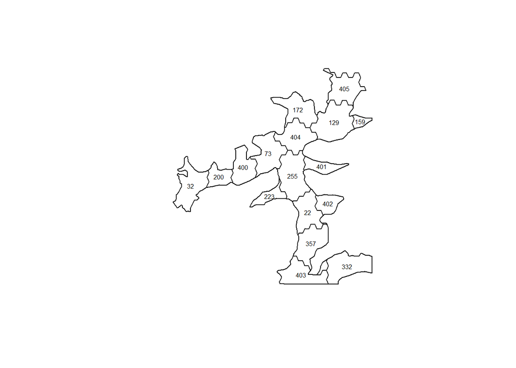

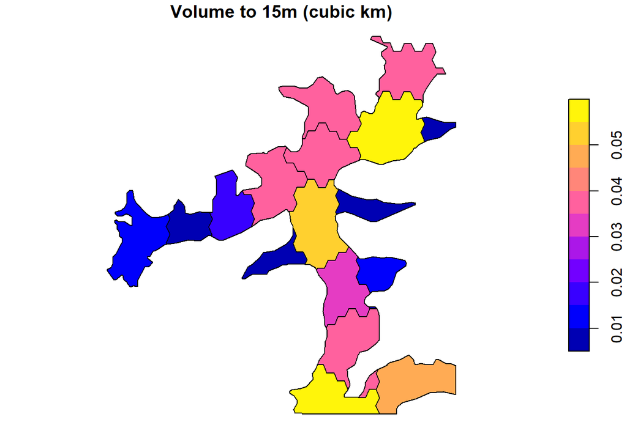

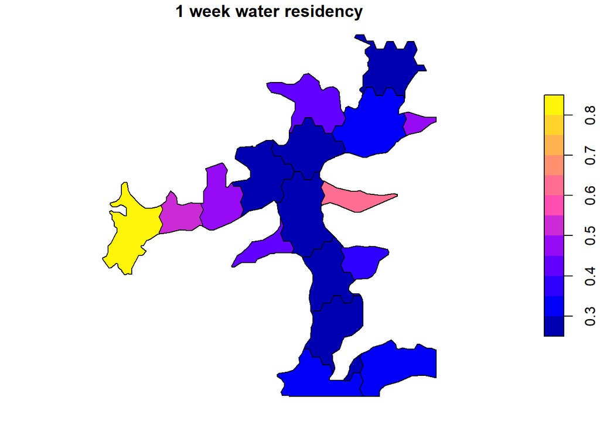

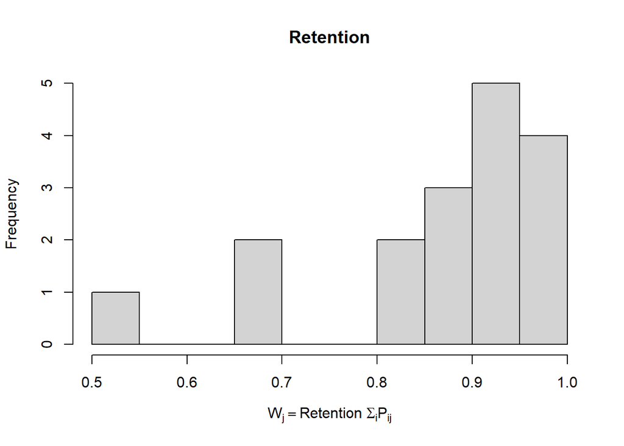

## Data on events

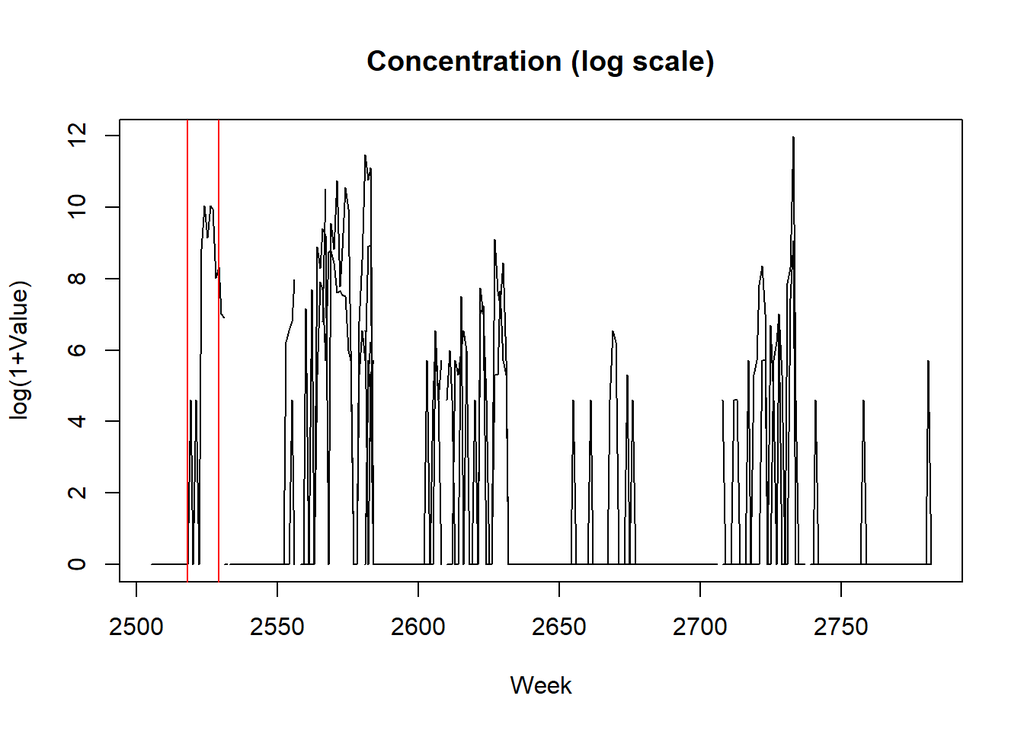

### Covariates

Residency: we have matrices $P_{ijt}$ for the weeks 2518-2529 (dates 2018-04-02-2018-06-18)

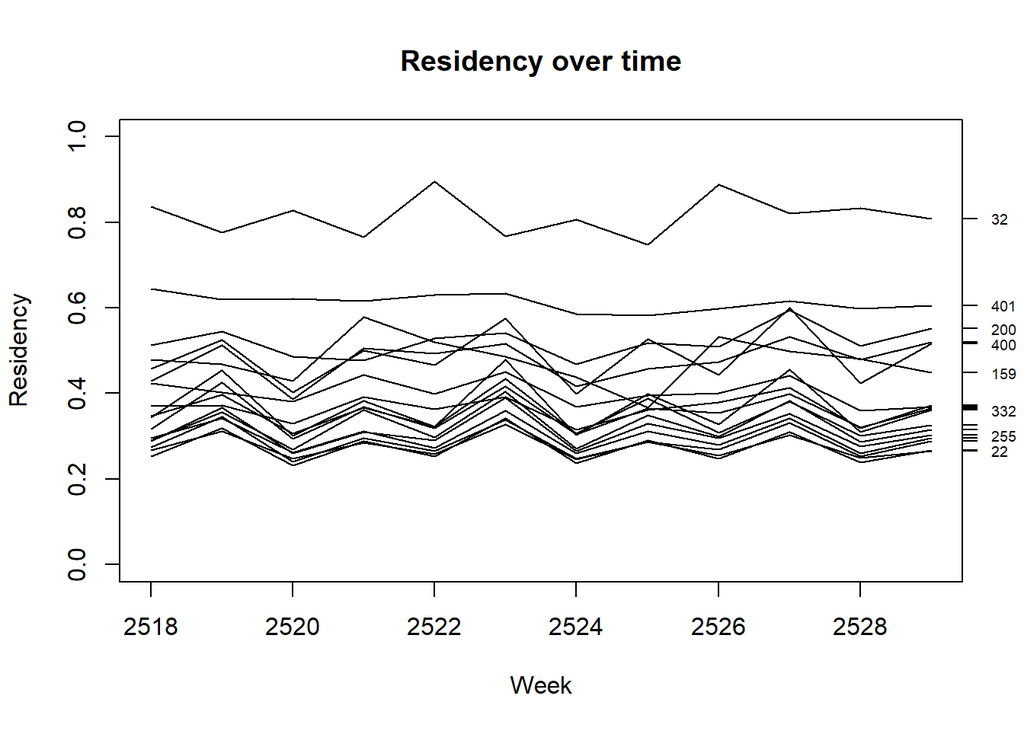

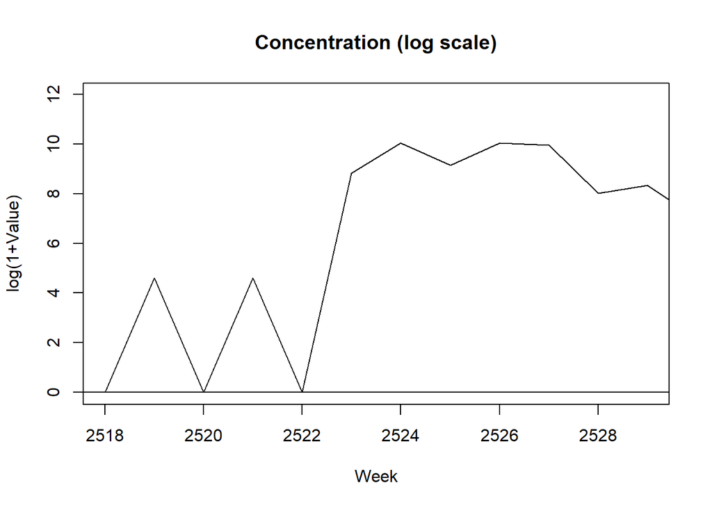

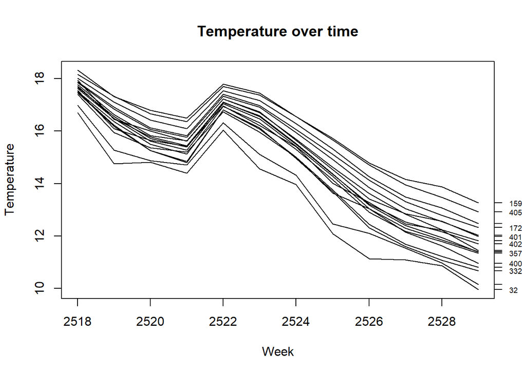

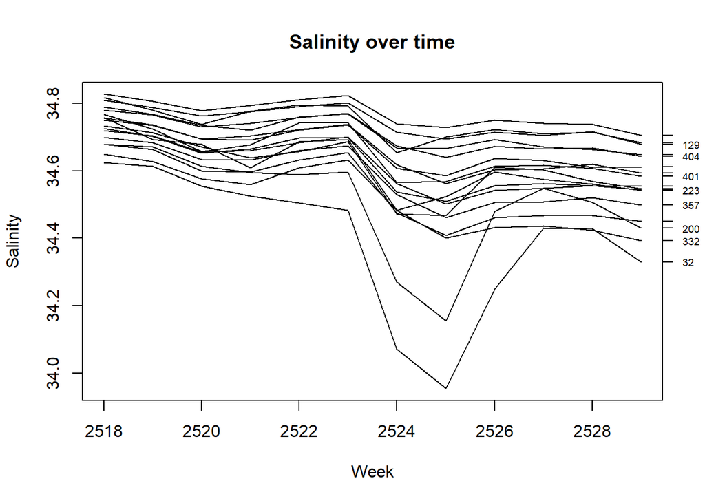

Temperature over time

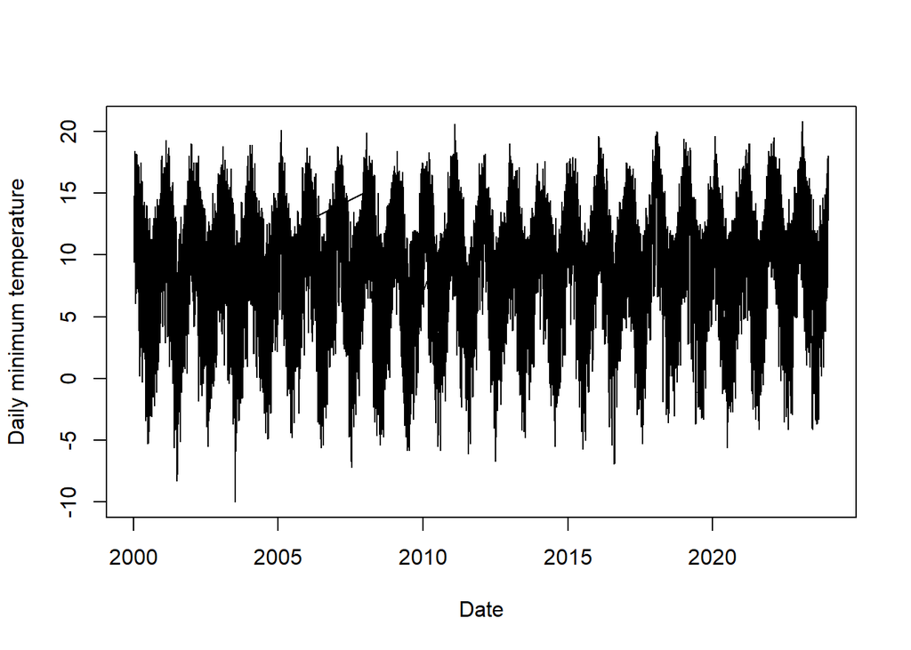

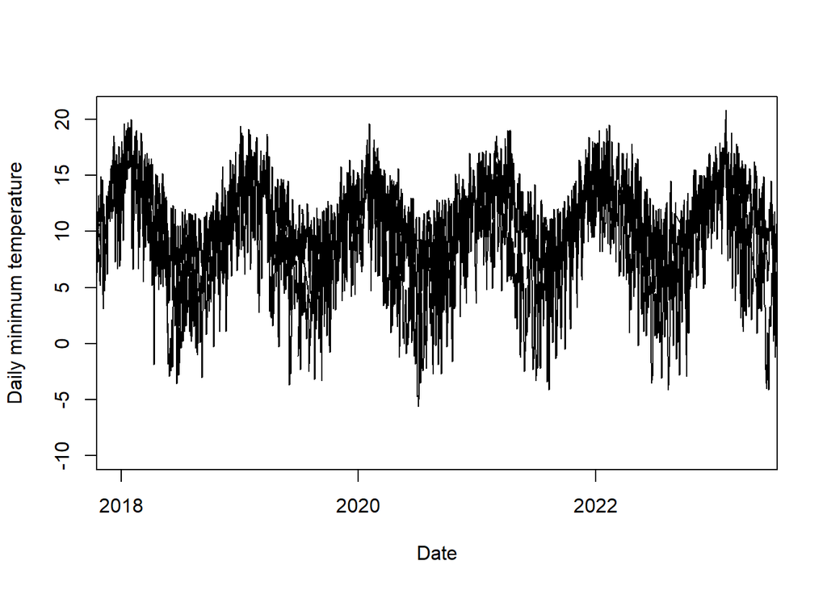

## Model implementation

Nydia polygons

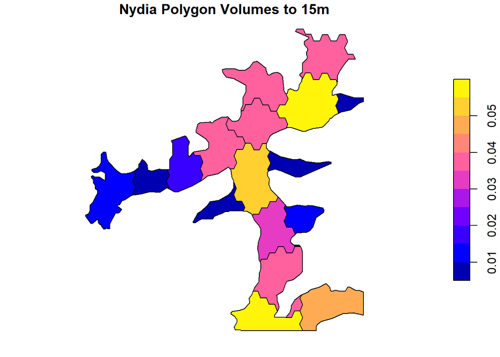

Communication matrix

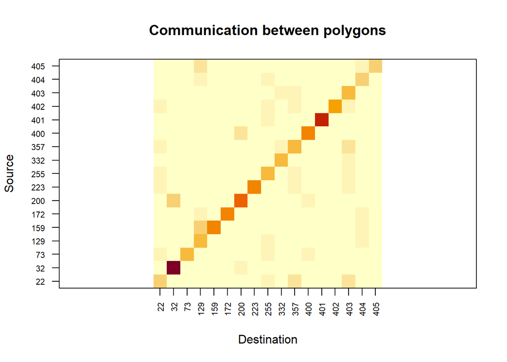

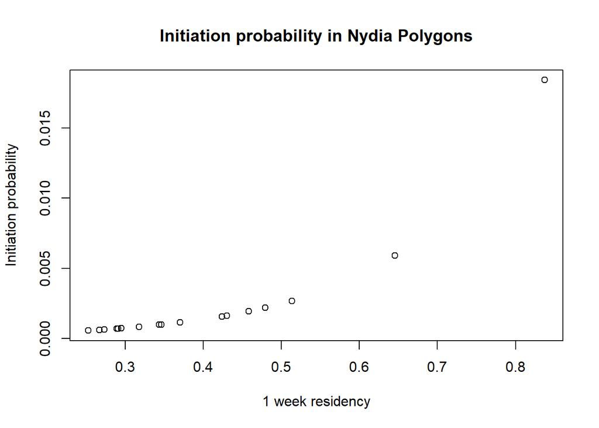

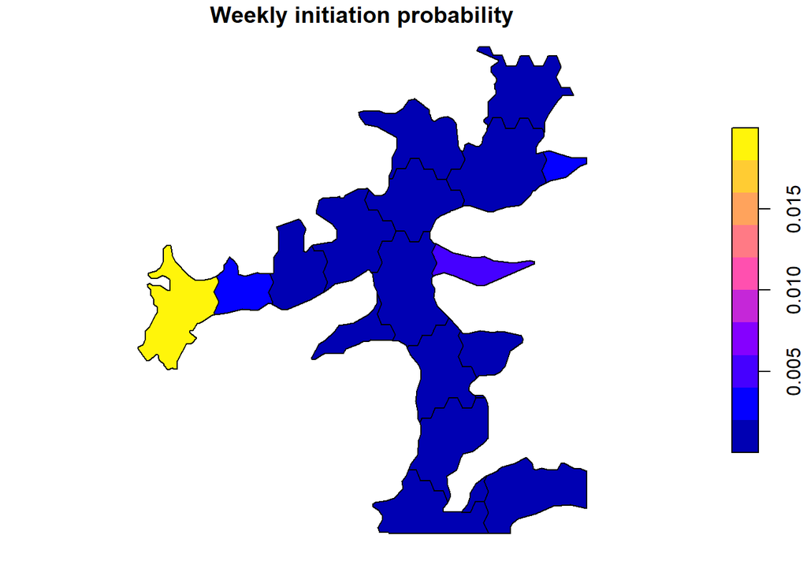

```
##  [1] 0 2 0 0 1 0 0 1 1 0 0 0 2 0 0 1 0
```

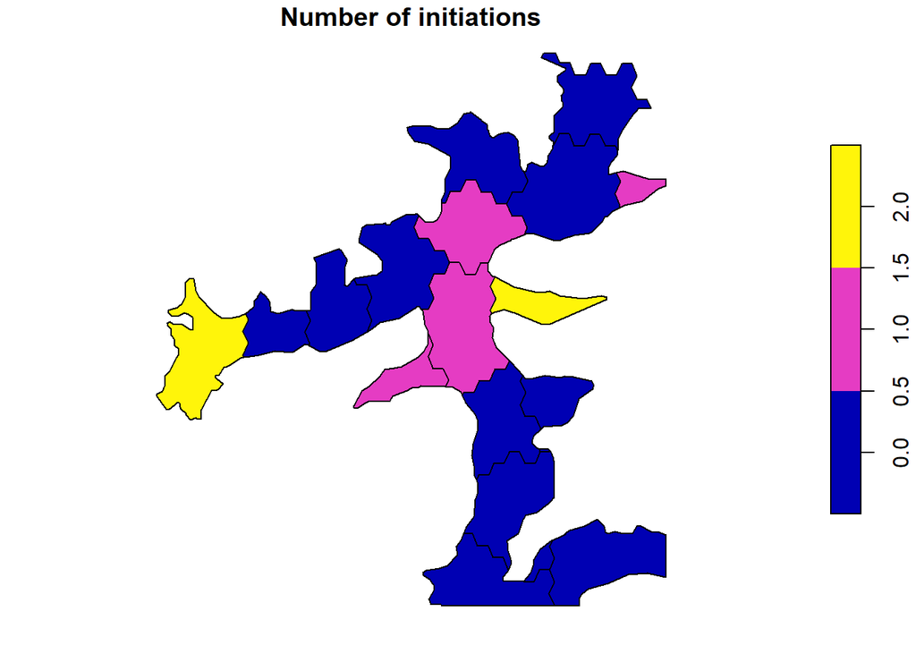

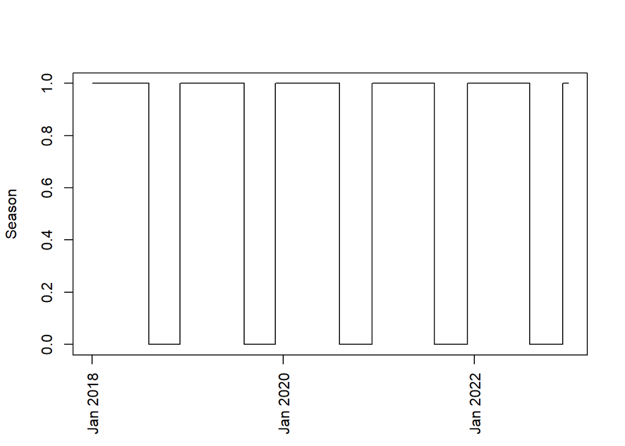